# Figure 3: Gold Standards

E. coli ORBIT 2023

Scott H. Saunders

# Notes

This figure contains several datatypes from experiments that were used benchmark ORBIT and compare to the lambda Red method. Data figures were made in R notebooks and exported as pdfs. Cosmetic improvements were made in Adobe Illustrator. Note that Figures 3A & 3C were made in Adobe Illustrator.

Setup packages and plotting for the notebook:

```r
# Check packages
source("../tools/package_setup.R")
# Load packages
library(tidyverse)
library(cowplot)
library(kableExtra)
# Code display options
knitr::opts_chunk$set(tidy.opts=list(width.cutoff=60),tidy=FALSE, echo = TRUE, message=FALSE, warning=FALSE, fig.align="center", fig.retina = 2)
# Load plotting tools
source("../tools/plotting_tools.R")
#Modify the plot theme
theme_set(theme_notebook())
```

# Fig. 3B - ORBIT vs. Lambda Red efficiency

Read in the ORBIT data.

```r
df_gold <- read_csv('../../data/low_throughput_experiments/2022_08_31_gold_stds.csv') %>% #read in csv
  mutate(eff = Kan_count / LB_count) %>% group_by(locus) %>% mutate(avg_eff = mean(eff)) #calculate efficiency and average efficiency for replicates

df_gold %>% kable() %>% kable_styling() %>% scroll_box(height = '250px')
```

locus

replicate

LB_count

Kan_count

eff

avg_eff

galK

1

870000

870

0.0010000

0.0014561

galK

2

1140000

1560

0.0013684

0.0014561

galK

3

760000

1520

0.0020000

0.0014561

hisA

1

970000

4100

0.0042268

0.0045716

hisA

2

860000

2600

0.0030233

0.0045716

hisA

3

990000

6400

0.0064646

0.0045716

metA

1

900000

2300

0.0025556

0.0035410

metA

2

600000

3300

0.0055000

0.0035410

metA

3

740000

1900

0.0025676

0.0035410

leuD

1

910000

350

0.0003846

0.0003861

leuD

2

850000

310

0.0003647

0.0003861

leuD

3

1100000

450

0.0004091

0.0003861

1

960000

44

0.0000458

0.0000562

2

800000

52

0.0000650

0.0000562

3

950000

55

0.0000579

0.0000562

Read in the lambda Red data.

```r
df_lam <- read_csv('../../data/low_throughput_experiments/2022_09_07_lambda_red_galK_AA_eff.csv') %>% #read in csv
  mutate(eff = Kan_count / LB_count) %>% group_by(locus) %>% mutate(avg_eff = mean(eff)) #calculate efficiency and average efficiency for replicates

df_lam %>% kable() %>% kable_styling() %>% scroll_box(height = '250px')
```

locus

replicate

LB_count

Kan_count

eff

avg_eff

galK

1

34000000

83

2.4e-06

2.8e-06

galK

2

52000000

124

2.4e-06

2.8e-06

galK

3

31000000

108

3.5e-06

2.8e-06

hisA

1

32000000

143

4.5e-06

3.5e-06

hisA

2

59000000

180

3.1e-06

3.5e-06

hisA

3

48000000

140

2.9e-06

3.5e-06

metA

1

18000000

96

5.3e-06

5.3e-06

metA

2

10400000

72

6.9e-06

5.3e-06

metA

3

20000000

73

3.7e-06

5.3e-06

leuD

1

16400000

31

1.9e-06

1.2e-06

leuD

2

66000000

49

7.0e-07

1.2e-06

leuD

3

26000000

29

1.1e-06

1.2e-06

1

21000000

8

4.0e-07

2.0e-07

2

35000000

3

1.0e-07

2.0e-07

3

27000000

5

2.0e-07

2.0e-07

Next we combine the ORBIT and lambda Red data and calculate the ratio of efficiencies:

```r
df_lam_gold <- bind_rows(df_gold %>% mutate(exp = 'ORBIT'), df_lam %>% mutate(exp = 'lambda_red')) %>%
  mutate(locus = factor(locus, levels =c('galK','hisA','metA','leuD','-'))) %>%
  mutate(exp = factor(exp, levels = c('ORBIT','lambda_red')))

df_lam_gold %>% filter(replicate == 1) %>%
  select(-LB_count,-Kan_count,-eff) %>%
  pivot_wider(names_from = exp, values_from = avg_eff) %>%
  mutate(orbit_lam_ratio = ORBIT / lambda_red)
```

```
## # A tibble: 5 × 5
## # Groups:   locus [5]
##   locus replicate     ORBIT  lambda_red orbit_lam_ratio
##   <fct>     <dbl>     <dbl>       <dbl>           <dbl>
## 1 galK          1 0.00146   0.00000277             526.
## 2 hisA          1 0.00457   0.00000348            1314.
## 3 metA          1 0.00354   0.00000530             668.
## 4 leuD          1 0.000386  0.00000125             309.
## 5 -             1 0.0000562 0.000000217            259.
```

Then we can plot the data:

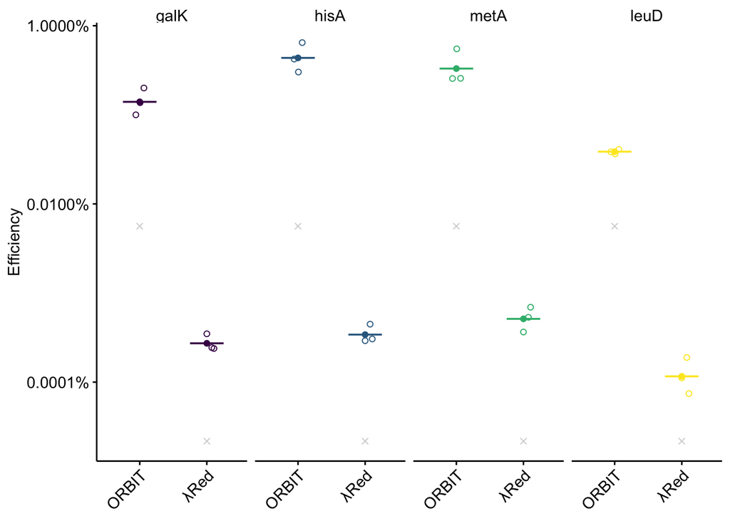

```r
#Calculate negative control values for ORBIT and lambda red
orbit_bg <- (df_lam_gold %>% filter(locus=='-' & exp == 'ORBIT'))$avg_eff[1]
lam_bg <-  (df_lam_gold %>% filter(locus=='-' & exp == 'lambda_red'))$avg_eff[1]

#Plot individual datapoints, mean dots and crossbars and negative control X's
plot_lam_gold <- ggplot(df_lam_gold %>% filter(locus!='-') %>% mutate(bg = ifelse(exp == 'ORBIT',orbit_bg, lam_bg)), aes(x = exp, y = eff , color = locus)) +
  geom_point(data = . %>% filter(replicate ==1), aes(y = bg), shape = 4, color= 'light gray')+
  stat_summary(fun = 'mean', geom = 'crossbar',width = 0.5, size = 0.25)+
  stat_summary(fun = 'mean', geom = 'point')+
  geom_point(position = position_jitterdodge(dodge.width = 1, jitter.width = 1), shape = 21) +
  facet_grid(~locus)+
  scale_color_viridis_d()+
  scale_y_log10(labels = scales::label_percent(accuracy = 0.0001), breaks = c(0.000001, 0.0001, 0.01)) +
  scale_x_discrete(labels = c('ORBIT','λRed'))+
  labs(y = 'Efficiency', x = NULL, fill = 'Strand') + guides(color = 'none') +
  theme(axis.text.x = element_text(angle = 45, hjust = 1))


plot_lam_gold
```

# Fig. 3D - ORBIT accuracy

These data are accuracy measurements where recombinants were tested for growth on permissive and selective media.

```r
df_gold_acc <- read_csv("../../data/low_throughput_experiments/2022_08_30_gold_std_2_accuracy.csv") %>%
    mutate(accuracy = 1-(selective_colonies / permissive_colonies)) %>%
  group_by(locus) %>%
  mutate(avg_accuracy = mean(accuracy)) %>%
  mutate(locus = factor(locus, levels = c('galK','hisA','metA','leuD')))

df_gold_acc %>% kable() %>% kable_styling() %>% scroll_box(height = '250px')
```

| locus | replicate | permissive_colonies | selective_colonies | accuracy | avg_accuracy |
| --- | --- | --- | --- | --- | --- |
| galK | 1 | 14 | 0 | 1.0000000 | 1.0000000 |
| galK | 2 | 14 | 0 | 1.0000000 | 1.0000000 |
| galK | 3 | 14 | 0 | 1.0000000 | 1.0000000 |
| hisA | 1 | 12 | 0 | 1.0000000 | 1.0000000 |
| hisA | 2 | 14 | 0 | 1.0000000 | 1.0000000 |
| hisA | 3 | 14 | 0 | 1.0000000 | 1.0000000 |
| metA | 1 | 14 | 0 | 1.0000000 | 1.0000000 |
| metA | 2 | 14 | 0 | 1.0000000 | 1.0000000 |
| metA | 3 | 14 | 0 | 1.0000000 | 1.0000000 |
| leuD | 1 | 14 | 0 | 1.0000000 | 0.9761905 |
| leuD | 2 | 14 | 1 | 0.9285714 | 0.9761905 |
| leuD | 3 | 14 | 0 | 1.0000000 | 0.9761905 |

Now let’s plot the data:

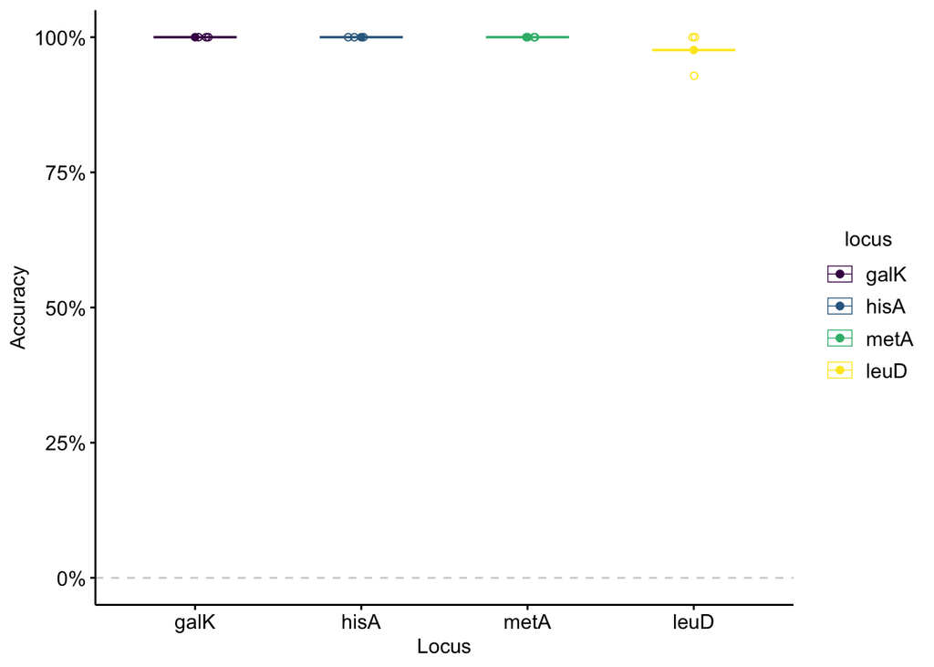

```r
plot_gold_acc <- ggplot(df_gold_acc, aes(x = locus, y = accuracy , color = locus)) +
  geom_hline(yintercept = 0, linetype =2, color = 'light gray')+ #negative control accuracy was 0
  stat_summary(fun = 'mean', geom = 'crossbar',width = 0.5, size = 0.25)+
  stat_summary(fun = 'mean', geom = 'point')+
  geom_jitter(width =0.1, height = 0, shape = 21) +
  scale_y_continuous(labels = scales::label_percent())+
  labs(y = 'Accuracy', x = 'Locus')+
 # facet_grid(~locus)+
  scale_color_viridis_d()

plot_gold_acc
```

# Create Fig. 3

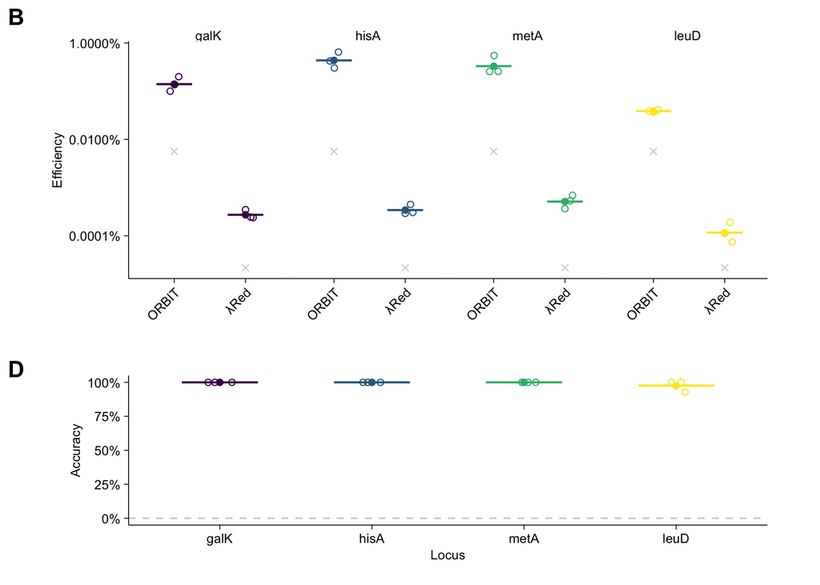

```r
theme_set(theme_figure())

fig_3_gold <- plot_grid(plot_lam_gold + guides(color = 'none'), plot_gold_acc + guides(color = 'none'), ncol = 1, rel_heights = c(1,0.66),
                   align = 'hv', axis = 'lr', scale = 0.9,
                   labels = c('B','D'))


fig_3_gold
```

```r
save_plot("../../figures/r_pdf_figs/main_figs/fig_3_gold_std.pdf", fig_3_gold, base_width = 3.5, base_height = 3.75)
```